# Lasquite_GIS

Hannah Lasquite

2026-06-23

```r
library(maps)
library(osmdata)
library(sf)
library(terra)
library(ggplot2)
library(tidyverse)
library(dplyr)
library(ggnewscale)
setwd("C:/Users/Acer/Desktop/LifeDat Projects/Act 9")
```

*2. Go to the Global Biodiversity Information Facility (GBIF) website. Create your account and download your assigned species records below as a CSV file (see Table). Use the species name when you search the data.*

```r
rawdata <- read.csv("Occurance Data.csv")
Mapdata <- select(rawdata, decimalLongitude, decimalLatitude, stateProvince)
Mapdata
```

```
##    decimalLongitude decimalLatitude                        stateProvince
## 1                NA              NA Autonomous Region in Muslim Mindanao
## 2          121.0423       14.575130 Autonomous Region in Muslim Mindanao
## 3          121.0423       14.575130 Autonomous Region in Muslim Mindanao
## 4                NA              NA                             Mindanao
## 5                NA              NA                             Mindanao
## 6                NA              NA                              Basilan
## 7                NA              NA                              Basilan
## 8                NA              NA                              Basilan
## 9                NA              NA                              Basilan
## 10               NA              NA                    Zamboanga del Sur
## 11               NA              NA                    Zamboanga del Sur
## 12               NA              NA                              Basilan
## 13               NA              NA                             Mindanao
## 14               NA              NA                             Mindanao
```

[output cut: 45 more lines]

*3. Clean the data by removing records found outside the reported species range.*

```r
#There's a ton of NA data with no coordinates or no Province. If there is no province I searched the coordinates up to check which Province it fell in. If there was no coordinates I removed it completely.

CleanMap <- Mapdata %>% drop_na(decimalLongitude, decimalLatitude)
#Removes any rows with missing Longitude or Latitude values


#Row 7 says the Province is Davao, Davao is no longer a singular province. Coordinates is in Davao Oriental.
CleanMap[7, "stateProvince"] <- "Davao Oriental"

#Rows 4, 5, 9, 11, 12 have empty Provinces. I am filling them in manually
CleanMap[4:5, "stateProvince"] <- "Agusan del Sur"
CleanMap[4:5, "stateProvince"] <- "Agusan del Sur"
CleanMap[9, "stateProvince"] <- "Misamis Oriental"
CleanMap[11:12, "stateProvince"] <- "Zamboanga del Sur"
CleanMap
```

```
##    decimalLongitude decimalLatitude                        stateProvince
## 1          121.0423       14.575130 Autonomous Region in Muslim Mindanao
## 2          121.0423       14.575130 Autonomous Region in Muslim Mindanao
## 3          125.5745        7.172830                        Davao del Sur
## 4          126.1493        8.257500                       Agusan del Sur
## 5          126.1493        8.257500                       Agusan del Sur
## 6          121.9667        6.700000                                 Sulu
## 7          126.1233        6.788600                       Davao Oriental
## 8          122.1969        7.266944                             Mindanao
## 9          124.7043        8.460700                     Misamis Oriental
## 10         125.4484        7.008070                        Davao del Sur
## 11         122.0930        7.039000                    Zamboanga del Sur
## 12         122.0930        7.039000                    Zamboanga del Sur
## 13         121.9712        6.704071                              Basilan
```

```r
#First two rows say the State Province is Autonomous Region in Muslim Mindanao, it does not correlate with its coordinates. The coordinates are actually in Mandaluyong?? No clue why but regardless its out of range so I sliced it away
FCleanMap <- CleanMap[-c(1:2), ]
FCleanMap
```

```
##    decimalLongitude decimalLatitude     stateProvince
## 3          125.5745        7.172830     Davao del Sur
## 4          126.1493        8.257500    Agusan del Sur
## 5          126.1493        8.257500    Agusan del Sur
## 6          121.9667        6.700000              Sulu
## 7          126.1233        6.788600    Davao Oriental
## 8          122.1969        7.266944          Mindanao
## 9          124.7043        8.460700  Misamis Oriental
## 10         125.4484        7.008070     Davao del Sur
## 11         122.0930        7.039000 Zamboanga del Sur
## 12         122.0930        7.039000 Zamboanga del Sur
## 13         121.9712        6.704071           Basilan
```

*4. Go to the DIVA-GIS website and download the Philippine administrative boundaries/areas. The zip file contains multiple shapefiles (adm0–3), representing different boundary levels (0-country; 1-provincial; 2-municipal; 3-barangay).* *5. Get only the provincial level, and subset the provinces that contain only distribution records for your assigned species.*

```r
neededProvince <- FCleanMap[, "stateProvince"]

provdata <- st_read("PHL_adm1.shp")
provcol <- select(provdata, NAME_1)

finalprov <- provcol %>%
  filter(NAME_1 %in% neededProvince)
finalprov
```

```
## Simple feature collection with 7 features and 1 field
## Geometry type: MULTIPOLYGON
## Dimension:     XY
## Bounding box:  xmin: 119.6388 ymin: 5.36528 xmax: 126.6053 ymax: 9.23514
## Geodetic CRS:  WGS 84
##              NAME_1                       geometry
## 1    Agusan del Sur MULTIPOLYGON (((125.9109 8....
## 2           Basilan MULTIPOLYGON (((121.9686 6....
## 3     Davao del Sur MULTIPOLYGON (((125.3978 5....
## 4    Davao Oriental MULTIPOLYGON (((126.0688 6....
## 5  Misamis Oriental MULTIPOLYGON (((124.6445 8....
## 6              Sulu MULTIPOLYGON (((120.8014 5....
## 7 Zamboanga del Sur MULTIPOLYGON (((122.0622 6....
```

*6.Go back to the DIVA-GIS website. Download the Philippine digital elevation model (“Elevation [country mask]”), then clip it using the provinces you selected in step 5.*

```r
PHMap <- rast("phMap.tif")

print(st_crs(finalprov) != st_crs(PHMap))
```

```
## [1] FALSE
```

```r
#Just to check if the coordinate systems are the same

FinalMap <- crop(PHMap, finalprov) |> mask(finalprov)
```

#B. Create your first map *1. Now, put all the data together into a map, following the pre-lab lecture. Make sure that data layers (points, polygons, DEMs) are arranged properly. Be creative!”*

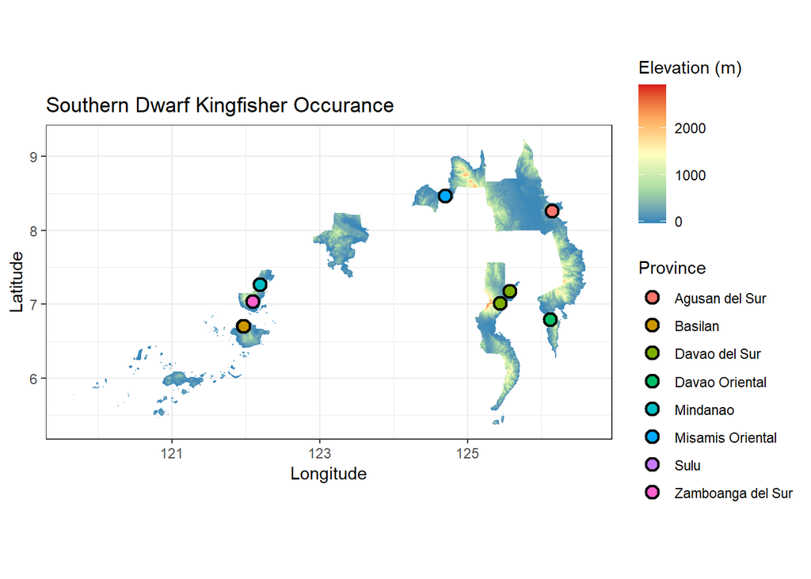

```r
MapDF <- as.data.frame(FinalMap, xy = TRUE)

ggplot() +
  geom_tile(data = MapDF, aes(x,y, fill = Band_1)) +
  scale_fill_gradientn(
    colors = c("#2b83ba", "#abdda4", "#ffffbf", "#fdae61", "#d7191c"),
    name = "Elevation (m)") +
new_scale_fill() +
  geom_point(data = FCleanMap,
             aes(x = decimalLongitude, y = decimalLatitude, fill = stateProvince),
             shape = 21,
             color = "black",
             size = 3,
             stroke = 1.2) +
  coord_equal() +
  labs(title = "Southern Dwarf Kingfisher Occurance",
       x = "Longitude",
       y = "Latitude",
       fill = "Province") +
  theme_bw()
```